# SDS/CSC 293 Mini-Project 2: Multiple Regression

Group 14: Heloise Cheruvalath, Karen Santamaria

Wednesday, March 6<sup>th</sup>, 2019

You will be submiting an entry to Kaggle’s [House Prices: Advanced Regression Techniques](https://www.kaggle.com/c/house-prices-advanced-regression-techniques/) by fitting a **multiple regression** model $\hat{f}(x)$.

# EDA

Read in data provided by Kaggle for this competition. They are organized in the `data/` folder of this RStudio project:

```r
training <- read_csv("data/train.csv")
test <- read_csv("data/test.csv")
sample_submission <- read_csv("data/sample_submission.csv")
```

Before performing any model fitting, you should always conduct an exploratory data analysis. This will help guide and inform your model fitting.

## Look at your data!

Always, ALWAYS, **ALWAYS** start by looking at your raw data. This gives you visual sense of what information you have to help build your predictive models. To get a full description of each variable, read the data dictionary in the `data_description.txt` file in the `data/` folder.

Note that the following code chunk has `eval = FALSE` meaning “don’t evaluate this chunk with knitting” because `.Rmd` files won’t knit if they include a `View()`:

```r
View(training)
glimpse(training)

View(test)
glimpse(test)
```

## Data wrangling

As much as possible, try to do all your data wrangling here:

```r
training <- training %>%
  select(Id, GrLivArea, BldgType, SalePrice, OverallQual, HalfBath, Foundation, SaleCondition)

training <- training %>%
  mutate(log10_SalePrice = log10(SalePrice),
         log10_GrLivArea = log10(GrLivArea)
         )

test <- test %>%
  mutate(
         log10_GrLivArea = log10(GrLivArea)
         )
```

# Minimally viable product

## Model fitting

```r
training <- training %>%
  sample_frac(1) %>%
  mutate(fold = rep(1:5, length = n())) %>%
  arrange(fold)

df = data.frame(fold = numeric(0), RMSLE = numeric(0))

model_1_formula <- as.formula("SalePrice~ GrLivArea + BldgType")



for(j in 1:5){
  pretend_training <- training %>%
    filter(fold != j)
  pretend_test <- training %>%
    filter(fold == j)

  # Fit model on pretend training
  model_1 <- lm(model_1_formula, data = pretend_training)

  fitted_points_1 <- model_1 %>%
    broom::augment(newdata = pretend_training)

  predicted_points_1 <- model_1 %>%
    broom::augment(newdata = pretend_test)

  rmsle_hat = MLmetrics::RMSLE(y_pred = predicted_points_1$.fitted, y_true = predicted_points_1$SalePrice)

  df[nrow(df) + 1,] = list(j,rmsle_hat)

}
```

# Due diligence

## Estimate of your Kaggle Score

```r
mean(df$RMSLE)
```

```
## [1] 0.2711361
```

## Create your submission CSV

```r
predict_test <- model_1 %>%
  broom::augment(newdata = test)


submission <- test %>%
  mutate(SalePrice = predict_test$.fitted) %>%
  select(Id,SalePrice)


write_csv(submission, path = "data/submission_due_diligence.csv")
```

## Screenshot of your Kaggle score

Our score based on our submission’s “Root Mean Squared Logarithmic Error” was 0.28756

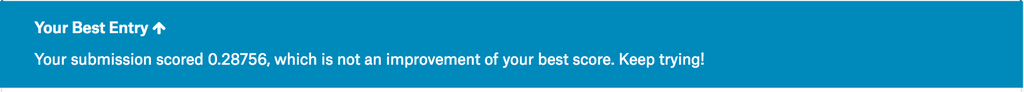

# Reaching for the stars

## Model fitting

```r
training <- training %>%
  sample_frac(1) %>%
  mutate(fold = rep(1:5, length = n())) %>%
  arrange(fold)

df2 = data.frame(fold = numeric(0), RMSLE = numeric(0))
model_2_formula <- as.formula("log10_SalePrice~ log10_GrLivArea + BldgType + OverallQual + HalfBath + Foundation + SaleCondition")



for(j in 1:5){
  pretend_training <- training %>%
    filter(fold != j)
  pretend_test <- training %>%
    filter(fold == j)

  # Fit model on pretend training
  model_2 <- lm(model_2_formula, data = pretend_training)

  fitted_points_2 <- model_2 %>%
    broom::augment(newdata = pretend_training)

  predicted_points_2 <- model_2 %>%
    broom::augment(newdata = pretend_test)

  pretend_test <- pretend_test %>%
    mutate(
      log10_SalePrice_hat = predicted_points_2$.fitted,
      SalePrice_hat = 10^log10_SalePrice_hat
    )

  rmsle_hat = MLmetrics::RMSLE(y_pred = pretend_test$SalePrice_hat, y_true = pretend_test$SalePrice)

  df2[nrow(df2) + 1,] = list(j,rmsle_hat)

}
```

## Estimate of your Kaggle score

```r
mean(df2$RMSLE)
```

```
## [1] 0.1827682
```

## Create your submission CSV

```r
predict_test2 <- model_2 %>%
  broom::augment(newdata = test)

submission <- test %>%
  mutate(
    log10_SalePrice = predict_test2$.fitted,
    SalePrice = 10^log10_SalePrice
    ) %>%
  select(Id,SalePrice)


write_csv(submission, path = "data/submission_reach_for_stars.csv")
```

## Screenshot of your Kaggle score

Our score based on our submission’s “Root Mean Squared Logarithmic Error” was 0.17383

[figure not shown]

# Point of diminishing returns

Find subset with largest adjusted R^2 for best subset selection

```r
regfit.full<-regsubsets(model_2_formula,data=training, nvmax=6)
reg.summary=summary(regfit.full)

plot(reg.summary$adjr2 ,xlab="Number of Variables ", ylab="Adjusted RSq",type="l")

which.max(reg.summary$adjr2)
```

```
## [1] 6
```

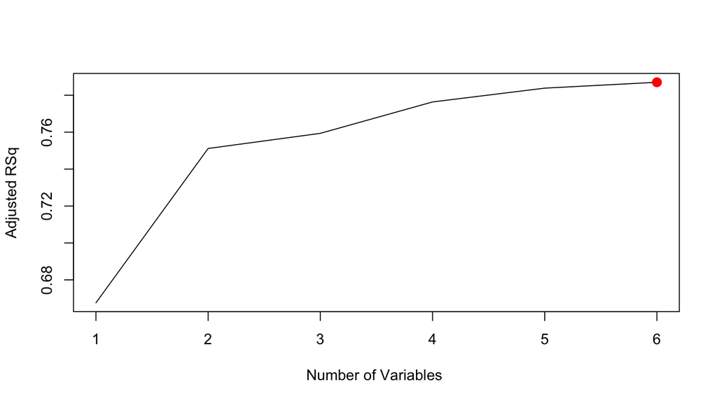

```r
points(6,reg.summary$adjr2[6], col="red",cex=2,pch=20)
```

```r
coef(regfit.full, 6)
```

```
##          (Intercept)      log10_GrLivArea        BldgTypeTwnhs
##           3.33182422           0.45262416          -0.08632810
##          OverallQual     FoundationCBlock      FoundationPConc
##           0.06312839           0.07676214           0.09564812
## SaleConditionPartial
##           0.03848463
```

Find subset with smallest adjusted RSS for best subset selection

```r
plot(reg.summary$rss ,xlab="Number of Variables ", ylab="RSS",type="l")

which.min(reg.summary$rss)
```

```
## [1] 6
```

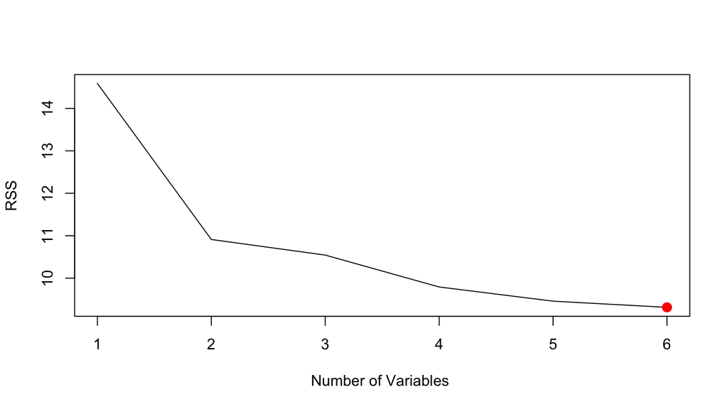

```r
points(6,reg.summary$rss[6], col="red",cex=2,pch=20)
```

## Estimate of your Kaggle score

```r
mean(df2$RMSLE)
```

```
## [1] 0.1827682
```

## Create your submission CSV

```r
predict_test2 <- model_2 %>%
  broom::augment(newdata = test)

submission <- test %>%
  mutate(
    log10_SalePrice = predict_test2$.fitted,
    SalePrice = 10^log10_SalePrice
    ) %>%
  select(Id,SalePrice)


write_csv(submission, path = "data/submission_diminishing_returns.csv")
```

## Screenshot of your Kaggle score

Our score based on our submission’s “Root Mean Squared Logarithmic Error” was 0.17383

[figure not shown]